# 02806 Social Data Analysis and Visualization

# Final Project B - Explainer Notebook

# 1. Motivation

The primary aim of the project was to explore the possible relationship between conflict and COVID-19. Social distancing has been a norm in most Western countries for the past months, and most 'non-essential' travel has been forbidden by authorities (or rendered impossible by transportation).

This got the authors thinking whether conflict, armed or otherwise, fell under this category. Is war put on hold out of fear for the virus? Are protests postponed to increase the safety of the masses? These were the questions that sparked this project.

We wanted to explore the relationship between the COVID-19 epidemic and conflict within the Middle-East. As it is a Data Visualization course, we of course thought of the best ways to portray this. We want the viewer to both see the scale of the virus and the conflict, this is achieved through overview- and heatmaps, and to gain an idea of whether there's a link between the two. This can be achieved mostly by aligning the data side-by-side or showing graphs. It is a curious subject, and we'd like the reader to take this question with them.

# 2. Basic Stats

## 2.1. Data cleaning and preprocessing

The following section will outline the preliminary data cleaning/settings needed to start working with the data sets.

```
Covid-19 data loaded. Total number of rows: 29792
         Date Country/Region  Confirmed  Recovered  Deaths
0  2020-01-22    Afghanistan        0.0        0.0     0.0
1  2020-01-23    Afghanistan        0.0        0.0     0.0
2  2020-01-24    Afghanistan        0.0        0.0     0.0
3  2020-01-25    Afghanistan        0.0        0.0     0.0
4  2020-01-26    Afghanistan        0.0        0.0     0.0
All conflict data loaded. Total number of rows: 197776
  EVENT_DATE  YEAR EVENT_TYPE  COUNTRY       LOCATION  LATITUDE  LONGITUDE  \
0 2016-01-01  2016   Protests  Bahrain       Ad Diraz    26.218     50.471
1 2016-01-01  2016   Protests  Bahrain      Al Maamir    26.133     50.609
2 2016-01-01  2016   Protests  Bahrain      Abu Saybi    26.218     50.507
3 2016-01-01  2016   Protests  Bahrain  Ash Shakhurah    26.215     50.507
4 2016-01-01  2016   Protests  Bahrain        Samahij    26.280     50.635

   FATALITIES  WEEK
0           0    53
1           0    53
2           0    53
3           0    53
4           0    53
```

### 2.1. cont.

As the COVID-19 data set only contains data from the year 2020, this is overkill. So we manually extracted the year 2020 out of the conflict data and loaded it in to a new variable. Additionally, we add the week of occurrence to the row, as we're going to be looking at the week in our timed heatmap movie.

```
2020 conflict data loaded. Total number of rows: 14347
  EVENT_DATE  YEAR EVENT_TYPE  COUNTRY   LOCATION  LATITUDE  LONGITUDE  \
0 2020-01-01  2020   Protests  Bahrain     Sitrah    26.155     50.621
1 2020-01-02  2020      Riots  Bahrain     Al Akr    26.143     50.610
2 2020-01-02  2020      Riots  Bahrain  Abu Saybi    26.218     50.507
3 2020-01-02  2020   Protests  Bahrain     Manama    26.228     50.586
4 2020-01-03  2020      Riots  Bahrain    Bu Quwa    26.205     50.520

   FATALITIES  WEEK
0           0     1
1           0     1
2           0     1
3           0     1
4           0     1
```

## 2.1. cont.

It's important to note that the COVID-19 data set contains a row for each country / region for each day since measurements started. Hence we want to both get the current cases and the cases over time within a certain time frame. The final date looked at is May 9th, 2020:

```
5 most prominent countries/regions in regards to confirmed COVID-19 cases:
Country/Region
US                1309550.0
Spain              223578.0
Italy              218268.0
United Kingdom     215260.0
Russia             198676.0
Name: Confirmed, dtype: float64
```

## 2.1. cont.

As can be seen, the COVID-19 dataset deals in global data, with the United States miles ahead in number of cases. We're only interested in looking at the Middle-East at the moment, so we'll make adjustments to our data:

## 2.1. cont.

Finally, to plot the data on a map, Folium is needed. Additionally, geojson data is required to assist in highlighting boundaries between the countries. This geojson was extracted from a larger geojson data set, gotten from https://acleddata.com/curated-data-files/.

## 2.2. Dataset stats

This section discusses dataset stats, and key points from our exploratory data analysis.

The conflict data has been filtered to the year 2020, and now uses a proper datetime format. Now we can learn more about this data set and what it can tell us:

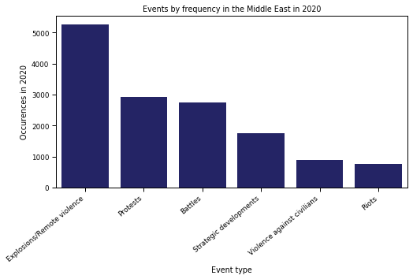

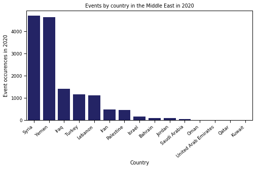

### 2.2. cont.

As can be seen, the countries most affected by conflict events are Syria and Yemen, followed by Iraq, Turkey and Lebanon.

The most common type of event in 2020 is unfortunately Explosions/Remote violence, followed by Protests and Battles.

As for the COVID-19 data, we want to look at the Middle-East specifically:

[output not shown]

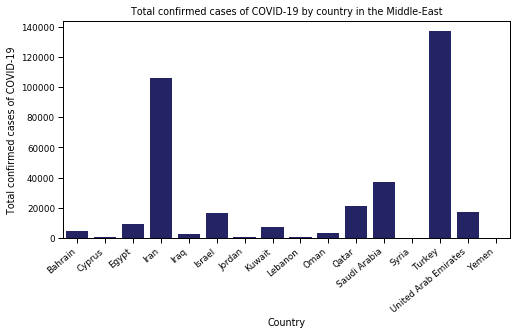

### 2.2. cont.

As can be seen, Turkey and Iran have the most confirmed cases by far. This poses a stark contrast to surrounding countries such as Jordan, Lebanon and Syria, all of which also have large populations. This is probably due to the fact of insufficient testing in these countries.

This analysis only tells part of the story. 'Confirmed' cases only indicates the total number of confirmed cases since measurements began. To get the current active cases, we have to subtract the number of deceased and the number of recovered. We'll do this by adding another column, "Active", to the dataframe:

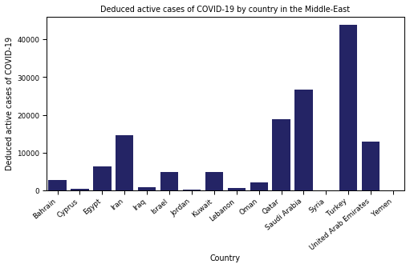

## 2.2. cont.

It's apparent that the virus is still alive and well in the Middle-east, with over 40,000 live cases in Turkey alone. This is of course hard to speculate, as patients recover slowly and the statistics cannot grasp this completely.

# 3. Data Analysis

### 3. cont.

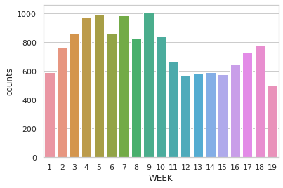

# 4. Genre

[interactive chart not shown]

# 6. Discussion

# 7. Contributions

# References